# Kursserver und Wordpress

9/25/2018

## Aufbau

1. Umgang mit Kursserver, RStudio und Worpress; Vorstellung von Ressourcen zu R (26.9) (LB)
2. Umgang mit verschiedenen Objekten in R und Datenbearbeitung mit tidyverse (10.10) (LB)
3. ggplot und plotly (24.10) (LB)
4. Loops und Funktionen; Apache Spark (7.11) (LB)
5. Helpdesk für Blogbeitrag (21.11) (LB)
6. Helpdesk für Blogbeitrag (5.12) (LB)
7. Helpdesk für Blogbeitrag (19.12) (LB)

## Was machen wir heute?

- Kursserver
  - Logins
  - Umgebung
  - Daten
  - Datentransfer
- Wordpress
  - Login
  - HTML vs. Text
  - Ressourcen
- Codesharing / Slack
- Ressourcen

## DISCLAIMER !!!

Die folgenden Befehele verwenden OSX-Syntax; Windows-User müssen alle `/` durch `\` ersetzen.

- Pfade in OSX:
  - `~/desktop/myfolder/deployments/`
- Pfade in WIN:
  - `\desktop\myfolder\deployments\` (falls ihr auf `C:` seid) oder
  - `C:/desktop/myfolder/deployments/`

Windows-User sollten noch [PuTTY downloaden](https://www.chiark.greenend.org.uk/~sgtatham/putty/latest.html), für eine Erweiterung der Terminal-Umgebung.

## Login für R-Umgebung

- URL1: http://130.60.130.9:8787/auth-sign-in
- URL2: http://pwipdm.uzh.ch:8787/auth-sign-in

[figure not shown]

## Login via Terminal [!deprecated!]

[figure not shown]

```bash
# connect to remote
local$ ssh USERNAME@pwipdm.uzh.ch
# enter password
```

Windows-User müssen ev. noch die [SSH-command enablen](https://www.howtogeek.com/336775/how-to-enable-and-use-windows-10s-built-in-ssh-commands/)

## Wo sind die Daten?

## Serverside

- auf dem Server: /home/BENUTZERNAME/Link-st-zh
- in der R-Umgebung:

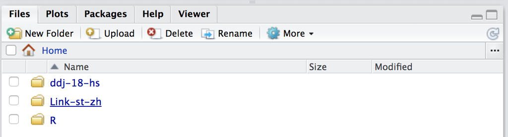

- Und wie kann ich die nun einlesen? In der Server-R-Umgebung:

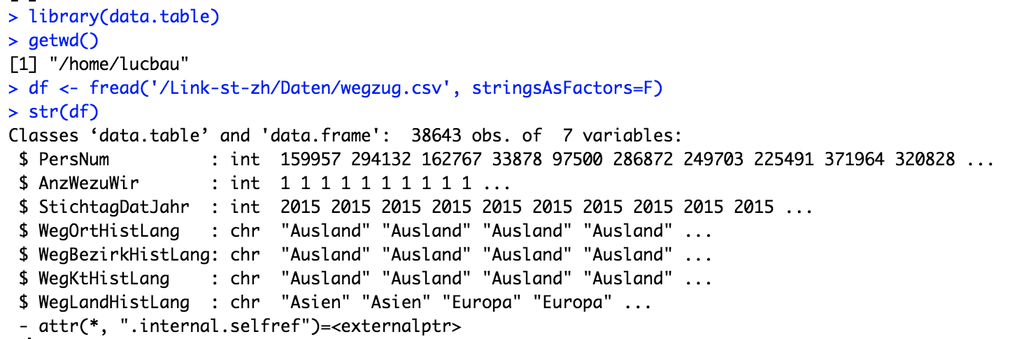

## Transfer from remote to local

Point and click ist am einfachsten:

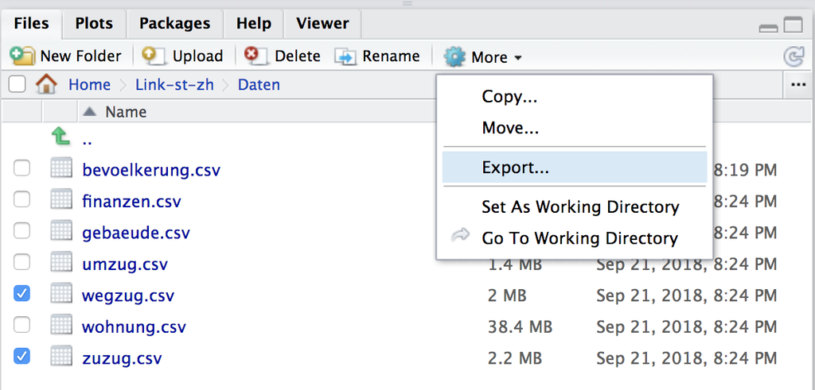

Ihr könnt natürlich gleich `~/Link-st-zh` als ganzes downloaden. ACHTUNG: Stabiles Internet, VPN

## Was dahinter geschieht

- transfer data from remote to local

```bash
# copy file
$ scp -r lucbau@pwipdm.uzh.ch:/home/lucbau/../Daten/wegzug.csv ~/temp/
# copy folder
$ scp -r lucbau@pwipdm.uzh.ch:/home/lucbau/../Daten ~/temp/
```

- transfer data from local to remote

```bash
# copy file
$ scp -r ~/temp/wegzug.csv lucbau@pwipdm.uzh.ch:/home/lucbau/../Daten/
# copy folder
$ scp -r ~/temp lucbau@pwipdm.uzh.ch:/home/lucbau/../Daten/
```

… wobei `~/ == /Users/lucienbaumgartner/`

## Wordpress

- [Link](http://pwiweb.uzh.ch/wordpress/wp-login.php)
- Neuen Blogbeitrag erstellen
- HTML vs. visual
- Dateien einfügen:
  - Dateien hochladen und einbinden (Format über HTML)
  - iframe

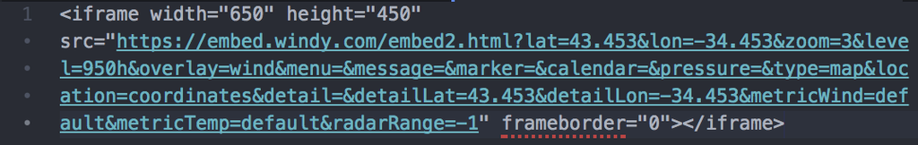

  - Add-ons (meldet euch!)
- Beiträge auf *privat* einstellen!
- Schaut euch die Beiträge der anderen User an und kopiert deren HTML-Elemente (Boxen, etc.)

## Hilfestellung

Bei Problemen oder Fragen

- GOOGLE
- Shared office im **AFL-G-261**; einfach vorbeischauen
- Mail
- Slack

Bei Errors:

- Script
- Paste des Errors / Console
- Benutzt bitte https://codeshare.io/ oder Slack R-Code-Snippets

Schämt euch nicht, Code Schreiben will auch gelernt sein.

## Ressourcen

## Basics

- [Methodenleitbuch](https://github.com/lucienbaumgartner/ddj18/res/Chair_Uebungsbuch_2015.pdf)
- [DataCamp R Intro](https://campus.datacamp.com/courses/free-introduction-to-r/chapter-1-intro-to-basics-1?ex=1)
- [RegexBuddy](https://www.regular-expressions.info/)
- [dplyr cheatsheet](https://www.rstudio.com/wp-content/uploads/2015/02/data-wrangling-cheatsheet.pdf)
- [dplyr Intro](https://rpubs.com/justmarkham/dplyr-tutorial)
- [FT Visual Vocab](https://github.com/ft-interactive/chart-doctor/blob/master/visual-vocabulary/Visual-vocabulary.pdf)
- [Stack overflow](https://stackoverflow.com/)

## Extended

- [Plot Layouts](https://cran.r-project.org/web/packages/egg/vignettes/Ecosystem.html)
- [R Graph Gallery](https://www.r-graph-gallery.com/)
- [Tidying spatial data](http://strimas.com/r/tidy-sf/)
- [Working with missing data in area plots](https://mattmazur.com/2017/04/19/removing-gaps-from-stacked-area-charts-in-r/)
- [plotly for R](https://plotly-book.cpsievert.me/index.html)
- [Little Inspiration (Capstone Website)](https://lucienbaumgartner.github.io/capstone_webdev/)